# 3. Data Cleaning

```python
import pandas as pd
import numpy as np
import seaborn as sns
import plotly.graph_objs as go
import random
import matplotlib.pyplot as plt

from PIL import Image
from plotly.offline import init_notebook_mode, iplot
from sklearn.ensemble import IsolationForest
from matplotlib import rcParams
rcParams['figure.figsize'] = 8,6
```

```python
cleandf = pd.read_csv('../data/loan_selected.csv', low_memory=False )
```

For the selection of the variables of the database and the subsequent treatment of their values we will use different methods, such as dummies creation, outliers and imputation of values. From the look of distributions, we will impute missing values with the median or other technique.

Before implementing the treatment methods on the variables, we check the length of the database after the selection of variables in the previous section.

```python
columnas = list(cleandf.columns)
```

```python
print(columnas)
```

[output not shown]

Now we check the type of data that the selected variables contain.

```python
cleandf.dtypes
```

```
loan_amnt                       int64
term                           object
int_rate                      float64
sub_grade                      object
emp_title                      object
emp_length                     object
home_ownership                 object
annual_inc                    float64
verification_status            object
purpose                        object
addr_state                     object
dti                           float64
earliest_cr_line               object
inq_last_6mths                float64
application_type               object
tot_cur_bal                   float64
total_rev_hi_lim              float64
bc_util                       float64
mort_acc                      float64
pct_tl_nvr_dlq                float64
pub_rec_bankruptcies          float64
tax_liens                     float64
total_il_high_credit_limit    float64
disbursement_method            object
target                          int64
desc                           object
dtype: object
```

```python
# plt.subplots(figsize=(15,10))
# myplot =  sns.heatmap(cleandf.isna(), cmap='GnBu_r')
```

```python
# fig = myplot.get_figure()
# fig.savefig("images/NaN_percentage.jpg", quality=95)
```

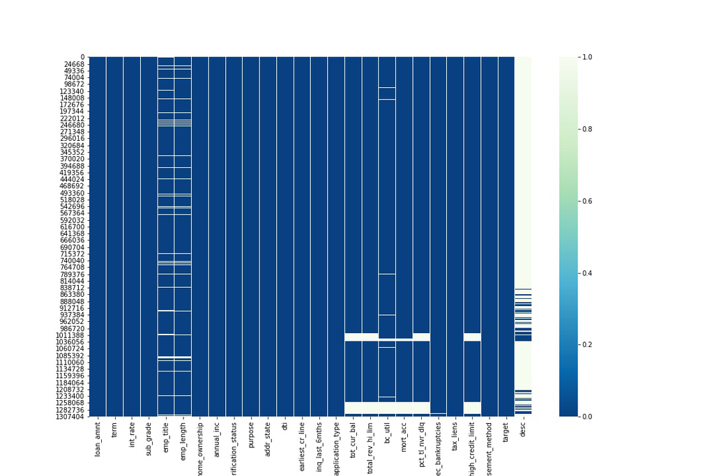

```python
img  = Image.open("../images/NaN_percentage.jpg")
img
```

## 3.1. Numerical features

We develop the same procedure for each of the numerical features. First, we see the descriptions and the histogram of frequencies to analyze the data. Then, we impute the missing values through the median, random imputation or othe method and finally we check if there are outliers and establish criteria to eliminate them.

```python
def fill_median(data, column):
    data[column].fillna(data[column].median(), inplace = True)
```

```python
def histogram(variable, bins=50):
    fig = sns.distplot(cleandf[f"{variable}"] ,hist=True, bins=bins, kde=False)
    return fig
```

```python
def distribution(variable):
    fig = cleandf.groupby(f'{variable}')['target'].value_counts(normalize=True).loc[:,1].plot(kind='bar')
    return fig
```

```python
def nulls(variable):
    return sum(cleandf[f'{variable}'].isnull())
```

```python
nulls('pct_tl_nvr_dlq')
```

```
70430
```

### 3.1.1. `loan_amnt`

**Definition**: The listed amount of the loan applied for by the borrower. If at some point in time, the credit department reduces the loan amount, then it will be reflected in this value.

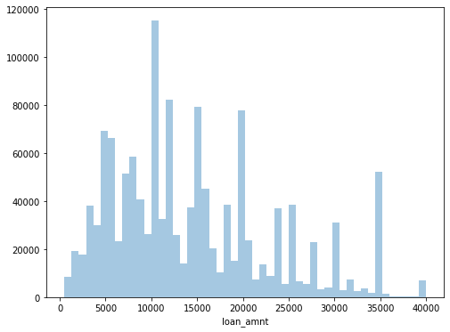

```python
histogram('loan_amnt');
```

```python
nulls('loan_amnt')
```

```
0
```

This variable doesn´t contain Na values.

### 3.1.2. `int_rate`

**Definition**: Interest Rate on the loan

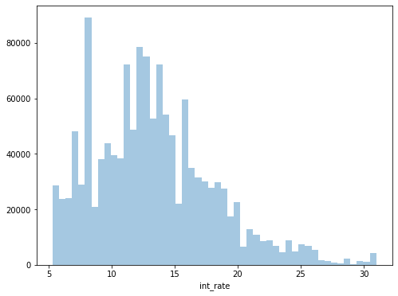

```python
histogram('int_rate');
```

```python
nulls('int_rate')
```

```
0
```

As in the previous case, this variable doesn´t contain outliers and Na values.

### 3.1.3. `annual_inc`

**Definition** : The self-reported annual income provided by the borrower during registration.

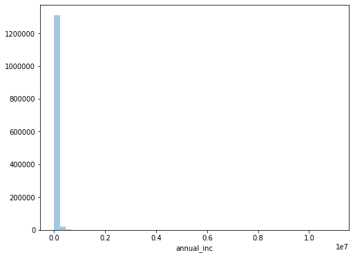

```python
histogram('annual_inc');
```

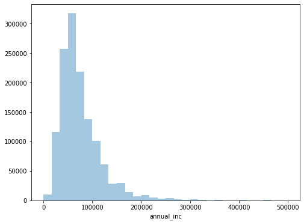

```python
sns.distplot(cleandf.query("annual_inc < 500000").annual_inc,hist=True, bins=30, kde=False);
```

We verify that the variable contains 4 Na values and we impute those values through the median.

```python
sum(cleandf['annual_inc'].isnull())
```

```
4
```

```python
fill_median(cleandf, 'annual_inc')
```

### 3.1.4. `dti`

**Definition**: A ratio calculated using the borrower’s total monthly debt payments on the total debt obligations, excluding mortgage and the requested LC loan, divided by the borrower’s self-reported monthly income.

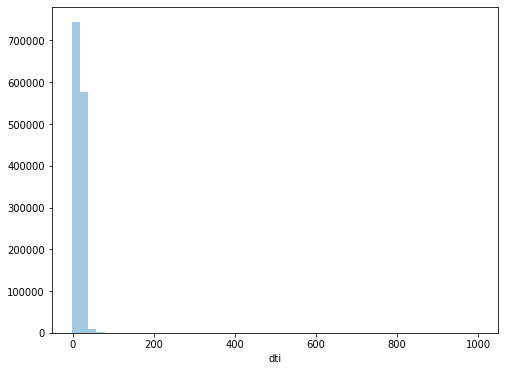

```python
histogram('dti');
```

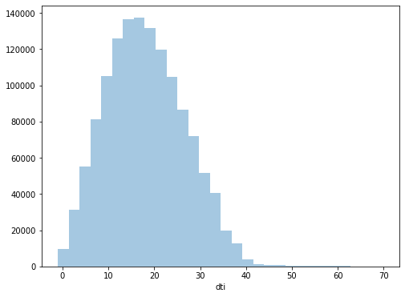

```python
sns.distplot(cleandf.query("dti < 70").dti,hist=True, bins=30, kde=False);
```

Imputation of the median in Na values.

```python
sum(cleandf['dti'].isnull())
```

```
348
```

```python
fill_median(cleandf, 'dti')
```

### 3.1.5. `inq_last_6mths`

**Definition**: The number of inquiries in past 6 months (excluding auto and mortgage inquiries).

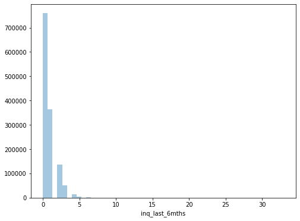

```python
histogram('inq_last_6mths');
```

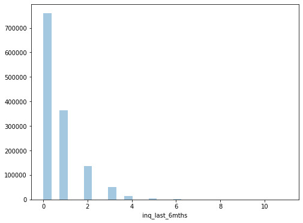

```python
sns.distplot(cleandf.query("inq_last_6mths < 12").inq_last_6mths, hist=True, bins=30, kde=False);
```

Imputation of the median in Na values.

```python
sum(cleandf['inq_last_6mths'].isnull())
```

```
30
```

```python
fill_median(cleandf, 'inq_last_6mths')
```

### 3.1.6. `tot_cur_bal`

**Definition**:Total current balance of all accounts.

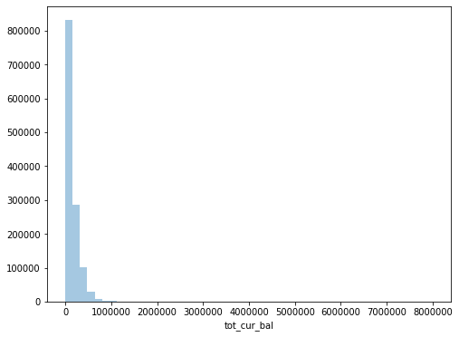

```python
histogram('tot_cur_bal');
```

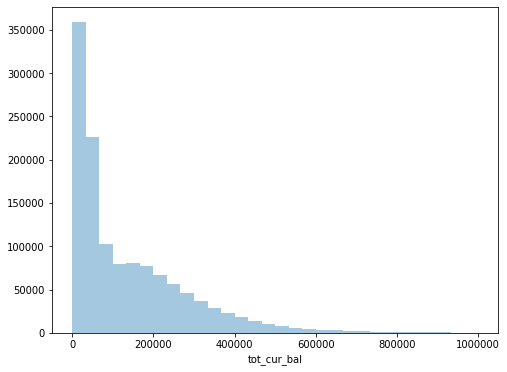

```python
sns.distplot(cleandf.query("tot_cur_bal < 1000000").tot_cur_bal,hist=True, bins=30, kde=False);
```

Imputation of the median in Na values.

```python
sum(cleandf['tot_cur_bal'].isnull())
```

```
70276
```

```python
fill_median(cleandf, 'tot_cur_bal')
```

### 3.1.7. `total_rev_hi_lim`

**Definition**: total revolving high credit/credit limit

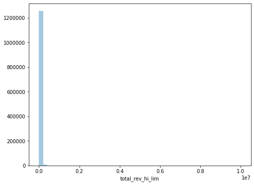

```python
histogram('total_rev_hi_lim');
```

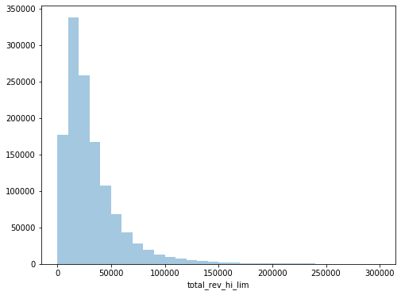

```python
sns.distplot(cleandf.query("total_rev_hi_lim < 300000").total_rev_hi_lim,hist=True, bins=30, kde=False);
```

Imputation of the median in Na values.

```python
sum(cleandf['total_rev_hi_lim'].isnull())
```

```
70276
```

```python
fill_median(cleandf, 'total_rev_hi_lim')
```

### 3.1.8. `bc_util`

**Definition**:ratio of total current balance to high credit/credit limit for all bankcard accounts.

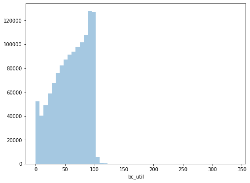

```python
histogram('bc_util');
```

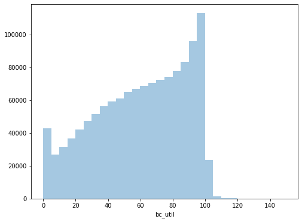

```python
sns.distplot(cleandf.query("bc_util < 150").bc_util, hist=True, bins=30, kde=False);
```

We impose random values between 4 and 22 on the Na values for containing a similar probability of default.

```python
sum(cleandf['bc_util'].isnull())
```

```
64542
```

```python
filtro = (cleandf["bc_util"].isna())
```

```python
cleandf[filtro]["target"].sum()/len(cleandf[filtro]["target"])
```

```
0.1715007282079886
```

```python
filtro = (cleandf["bc_util"] <= 22) & (cleandf["bc_util"] >= 4)
```

```python
cleandf[filtro]["target"].sum()/len(cleandf[filtro]["target"])
```

```
0.1712700128524858
```

```python
cleandf['bc_util'].fillna(-1, inplace = True)
```

```python
cleandf['bc_util'] =  cleandf['bc_util'].map(lambda v: (random.randint(40,220)/10) if v == -1 else v)
```

```python
sum(cleandf['bc_util'].isnull())
```

```
0
```

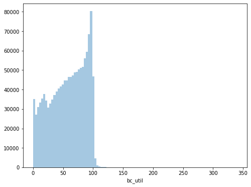

```python
histogram('bc_util', 100);
```

### 3.1.9. `mort_acc`

**Definition**: Number of mortgage accounts.

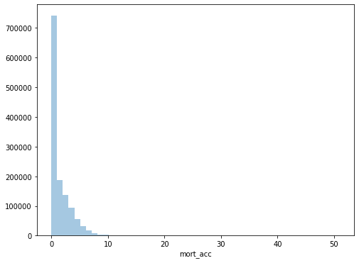

```python
histogram('mort_acc');
```

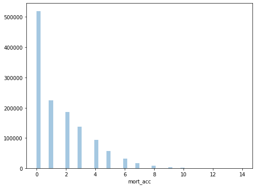

```python
sns.distplot(cleandf.query("mort_acc < 15").mort_acc, hist=True, bins=50, kde=False);
```

The percentage of non-payment of individuals who don´t contain information is very close to individuals who have 6 mortgages. It may be a better procedure than imputing the median.

```python
sum(cleandf['mort_acc'].isnull())
```

```
50030
```

```python
cleandf[cleandf["mort_acc"].isna()]["target"].sum()/len(cleandf[cleandf["mort_acc"].isna()]["target"])
```

```
0.15284829102538477
```

```python
cleandf[cleandf["mort_acc"] == 6]["target"].sum()/len(cleandf[cleandf["mort_acc"] == 6]["target"])
```

```
0.15475930830347406
```

```python
cleandf['mort_acc'].fillna(6, inplace = True)
```

### 3.1.10. `pct_tl_nvr_dlq`

**Definition**: percent of trades never delinquent.

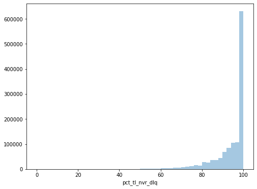

```python
histogram('pct_tl_nvr_dlq');
```

For the clients that we don´t have information about we can see that their default rate is lower than the rest, so we will impute the Na values with random values between 95 and 100.

```python
sum(cleandf['pct_tl_nvr_dlq'].isnull())
```

```
70430
```

```python
filtro = (cleandf["pct_tl_nvr_dlq"].isnull())

cleandf[filtro]["target"].sum()/len(cleandf[filtro]["target"])
```

```
0.15761749254579013
```

```python
 cleandf['pct_tl_nvr_dlq'].fillna(-1, inplace = True)
```

```python
 cleandf['pct_tl_nvr_dlq'] =  cleandf['pct_tl_nvr_dlq'].map(lambda v: (random.randint(950,1000)/10) if v == -1 else v)
```

### 3.1.11. `pub_rec_bankruptcies`

**Definition**: number of public record bankruptcies.

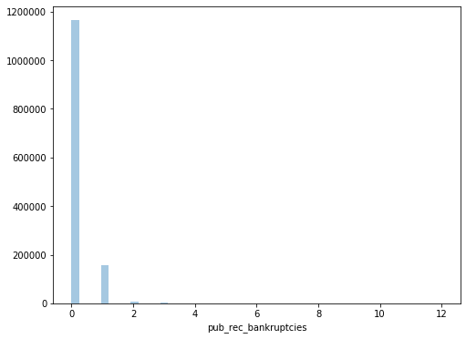

```python
histogram('pub_rec_bankruptcies');
```

Imputation of the median in Na values.

```python
fill_median(cleandf, 'pub_rec_bankruptcies')
```

```python
sum(cleandf['pub_rec_bankruptcies'].isnull())
```

```
0
```

```
1. zero bankruptcies
2. one bankruptcies
3. more than one bankruptcies
```

```python
# cleandf['pub_rec_bankruptcies'] =  cleandf['pub_rec_bankruptcies'].map(lambda v: "zero" if v == 0 else "one" if v == 1 else "more than 1")
```

### 3.1.12. `tax_liens`

**Definition**: number of tax liens

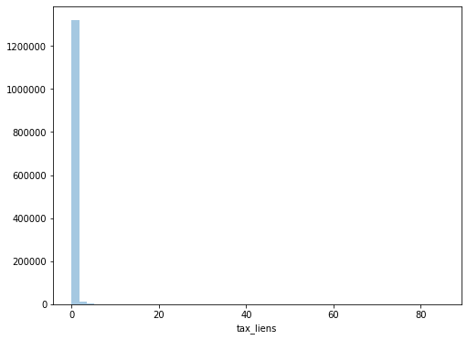

```python
histogram('tax_liens');
```

```python
sum(cleandf['tax_liens'].isnull())
```

```
105
```

Imputation of the median in Na values.

```python
fill_median(cleandf, 'tax_liens')
```

```python
sum(cleandf['tax_liens'].isnull())
```

```
0
```

### 3.1.13. `total_il_high_credit_limit`

**Definition**: total installment high credit/credit limit

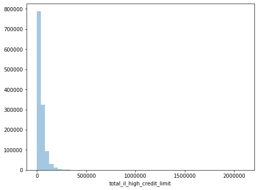

```python
histogram('total_il_high_credit_limit');
```

Imputation of the median in Na values.

```python
sum(cleandf['total_il_high_credit_limit'].isnull())
```

```
70276
```

```python
fill_median(cleandf, 'total_il_high_credit_limit')
```

## 3.2. Categorical features

In the categorical features we will apply the same concerns as in the numerical variables.

### 3.2.1. `emp_length`

**Definition**: employment length in years. Possible values are between 0 and 10 where 0 means less than one year and 10 means ten or more years.

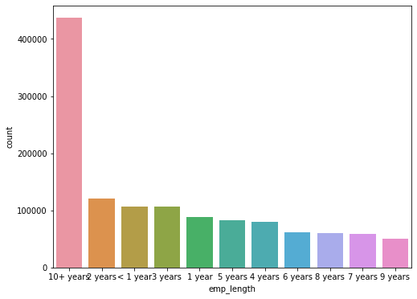

```python
sns.countplot(cleandf['emp_length'], order = cleandf['emp_length'].value_counts().index)
```

```python
sum(cleandf['emp_length'].isnull())
```

```
77856
```

```python
filtro = (cleandf["emp_length"].isnull())
cleandf[filtro]["target"].sum()/len(cleandf[filtro]["target"])
```

```
0.2925529182079737
```

The `emp_length` variable contains many NAs values so we check that the individuals who don´t offer this information pay badly. We decide to create a new category "without response".

```python
 cleandf['emp_length'].fillna("No responde", inplace = True)
```

```python
sum(cleandf['emp_length'].isnull())
```

```
0
```

### 3.2.2. `sub_grade`

**Definition**: LendingClub assigned loan subgrade

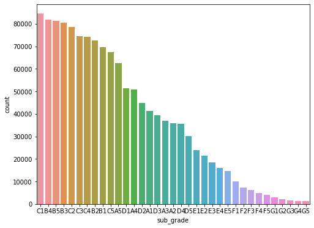

```python
sns.countplot(cleandf['sub_grade'], order = cleandf['sub_grade'].value_counts().index)
```

```python
sum(cleandf['sub_grade'].isnull())
```

```
0
```

### 3.2.3. `home_ownership`

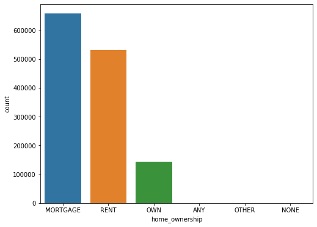

```python
sns.countplot(cleandf['home_ownership'], order = cleandf['home_ownership'].value_counts().index)
```

```python
sum(cleandf['home_ownership'].isnull())
```

```
0
```

### 3.2.4. `verification_status`

**Definition**: indicates if income was verified by LC, not verified, or if the income source was verified.

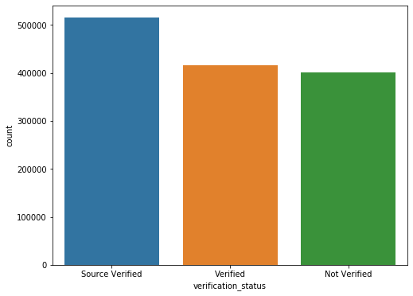

```python
sns.countplot(cleandf['verification_status']);
```

```python
sum(cleandf['verification_status'].isnull())
```

```
0
```

### 3.2.5. `purpose`

**Definition**: a category provided by the borrower for the loan request.

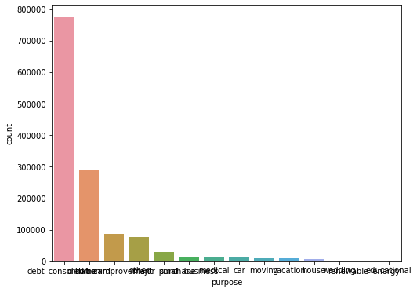

```python
sns.countplot(cleandf['purpose'] , order = cleandf['purpose'].value_counts().index)
```

```python
sum(cleandf['purpose'].isnull())
```

```
0
```

### 3.2.6. `addr_state`

**Definition**: The state provided by the borrower in the loan application.

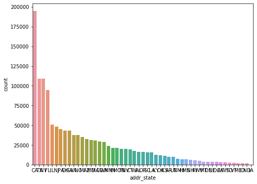

```python
sns.countplot(cleandf['addr_state'] , order = cleandf['addr_state'].value_counts().index)
```

```python
sum(cleandf['addr_state'].isnull())
```

```
0
```

### 3.2.7. `earliest_cr_line`

**Definition**: the date the borrower's earliest reported credit line was opened

```python
sum(cleandf['earliest_cr_line'].isnull())
```

```
29
```

We delete the records without information of this variable

```python
cleandf = cleandf[cleandf['earliest_cr_line'].notnull()]
```

### 3.2.8. `application_type`

**Definition**: indicates whether the loan is an individual application or a joint application with two co-borrowers.

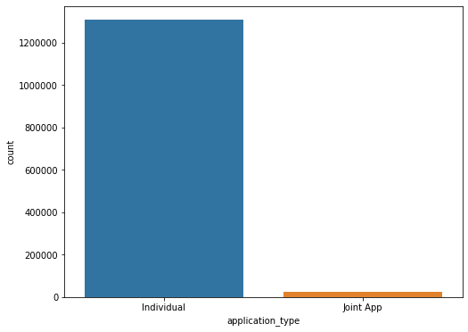

```python
sns.countplot(cleandf['application_type'] , order = cleandf['application_type'].value_counts().index)
```

```python
sum(cleandf['application_type'].isnull())
```

```
0
```

### 3.2.9. `disbursement_method`

**Definition**: Paying method, cash or directpay

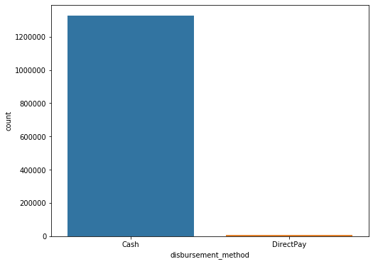

```python
sns.countplot(cleandf['disbursement_method'] , order = cleandf['disbursement_method'].value_counts().index)
```

```python
sum(cleandf['disbursement_method'].isnull())
```

```
0
```

```python
cleandf.columns
```

```
Index(['loan_amnt', 'term', 'int_rate', 'sub_grade', 'emp_title', 'emp_length',
       'home_ownership', 'annual_inc', 'verification_status', 'purpose',
       'addr_state', 'dti', 'earliest_cr_line', 'inq_last_6mths',
       'application_type', 'tot_cur_bal', 'total_rev_hi_lim', 'bc_util',
       'mort_acc', 'pct_tl_nvr_dlq', 'pub_rec_bankruptcies', 'tax_liens',
       'total_il_high_credit_limit', 'disbursement_method', 'target', 'desc'],
      dtype='object')
```

```python
#specify the metric column names to be modelled
numeric = cleandf.select_dtypes(include = [np.number])
to_model_columns = numeric.columns
clf=IsolationForest(n_estimators=100, max_samples='auto', contamination=float(.04), \
                        max_features=1.0, bootstrap=False, n_jobs=5, random_state=42, verbose=0)
clf.fit(cleandf[to_model_columns])
pred = clf.predict(cleandf[to_model_columns])
cleandf['anomaly']=pred
outliers=cleandf.loc[cleandf['anomaly']==-1]
outlier_index=list(outliers.index)
#print(outlier_index)
#Find the number of anomalies and normal points here points classified -1 are anomalous
print(cleandf['anomaly'].value_counts())
```

```
 1    1278712
-1      53280
Name: anomaly, dtype: int64
```

```python
cleandf.head()
```

|  | loan_amnt | term | int_rate | sub_grade | emp_title | emp_length | home_ownership | annual_inc | verification_status | purpose | ... | bc_util | mort_acc | pct_tl_nvr_dlq | pub_rec_bankruptcies | tax_liens | total_il_high_credit_limit | disbursement_method | target | desc | anomaly |
| --- | --- | --- | --- | --- | --- | --- | --- | --- | --- | --- | --- | --- | --- | --- | --- | --- | --- | --- | --- | --- | --- |
| 0 | 30000 | 36 months | 22.35 | D5 | Supervisor | 5 years | MORTGAGE | 100000.0 | Source Verified | debt_consolidation | ... | 46.9 | 1.0 | 89.5 | 1.0 | 0.0 | 101984.0 | Cash | 0 | NaN | 1 |
| 1 | 40000 | 60 months | 16.14 | C4 | Assistant to the Treasurer (Payroll) | < 1 year | MORTGAGE | 45000.0 | Verified | credit_card | ... | 67.3 | 1.0 | 100.0 | 0.0 | 0.0 | 167965.0 | Cash | 0 | NaN | 1 |
| 2 | 20000 | 36 months | 7.56 | A3 | Teacher | 10+ years | MORTGAGE | 100000.0 | Not Verified | credit_card | ... | 29.9 | 5.0 | 94.7 | 0.0 | 0.0 | 74833.0 | Cash | 0 | NaN | 1 |
| 3 | 4500 | 36 months | 11.31 | B3 | Accounts Examiner III | 10+ years | RENT | 38500.0 | Not Verified | credit_card | ... | 28.9 | 0.0 | 91.7 | 0.0 | 0.0 | 24595.0 | Cash | 0 | NaN | 1 |
| 4 | 8425 | 36 months | 27.27 | E5 | Senior Director Risk Management | 3 years | MORTGAGE | 450000.0 | Verified | credit_card | ... | 74.6 | 4.0 | 100.0 | 0.0 | 0.0 | 189054.0 | Cash | 0 | NaN | -1 |

5 rows × 27 columns

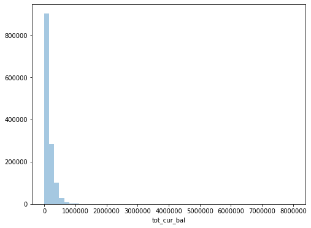

```python
histogram('tot_cur_bal');
```

```python
cleandf = cleandf[cleandf['anomaly'] != -1]
```

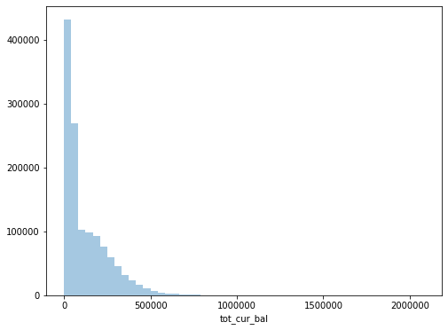

```python
histogram('tot_cur_bal');
```

```python
cleandf.drop('anomaly', axis=1, inplace=True)
```

```python
cleandf.head()
```

|  | loan_amnt | term | int_rate | sub_grade | emp_title | emp_length | home_ownership | annual_inc | verification_status | purpose | ... | total_rev_hi_lim | bc_util | mort_acc | pct_tl_nvr_dlq | pub_rec_bankruptcies | tax_liens | total_il_high_credit_limit | disbursement_method | target | desc |
| --- | --- | --- | --- | --- | --- | --- | --- | --- | --- | --- | --- | --- | --- | --- | --- | --- | --- | --- | --- | --- | --- |
| 0 | 30000 | 36 months | 22.35 | D5 | Supervisor | 5 years | MORTGAGE | 100000.0 | Source Verified | debt_consolidation | ... | 42200.0 | 46.9 | 1.0 | 89.5 | 1.0 | 0.0 | 101984.0 | Cash | 0 | NaN |
| 1 | 40000 | 60 months | 16.14 | C4 | Assistant to the Treasurer (Payroll) | < 1 year | MORTGAGE | 45000.0 | Verified | credit_card | ... | 54200.0 | 67.3 | 1.0 | 100.0 | 0.0 | 0.0 | 167965.0 | Cash | 0 | NaN |
| 2 | 20000 | 36 months | 7.56 | A3 | Teacher | 10+ years | MORTGAGE | 100000.0 | Not Verified | credit_card | ... | 85100.0 | 29.9 | 5.0 | 94.7 | 0.0 | 0.0 | 74833.0 | Cash | 0 | NaN |
| 3 | 4500 | 36 months | 11.31 | B3 | Accounts Examiner III | 10+ years | RENT | 38500.0 | Not Verified | credit_card | ... | 29200.0 | 28.9 | 0.0 | 91.7 | 0.0 | 0.0 | 24595.0 | Cash | 0 | NaN |
| 5 | 20000 | 60 months | 17.97 | D1 | Front office Lead | 4 years | RENT | 57000.0 | Not Verified | debt_consolidation | ... | 72700.0 | 50.4 | 1.0 | 100.0 | 0.0 | 0.0 | 0.0 | Cash | 0 | NaN |

5 rows × 26 columns

```python
# save to local disk
cleandf.to_csv('../data/loan_cleaned.csv', index=False)
```